# L22

# Development to Deployment

- Some bugs only appear under stress
- Prod environment is not the same as the dev env
- Deployment exposes your app in ways your app was *not* meant to be used
  - Evil forces
  - Idiots

## Early Deployment Strategies

- Need a Virtual Private Server (VPS)
  - Might be in cloud eg: AWS
- Install and configure OS and all utilities needed for the app
- Fix almost-weekly security vulnerabilities
- Tune all moving parts to get most bang for buck
- Figure out how to automate horizontal scaling

## Platform as a Service (PaaS)

- Easy tiers of horizontal scaling
- Component-level performance tuning
- Infrastructure-level security
- App devs still have to worry about usage and efficiency of app

## Performance Metrics

- Availability / uptime ≙ percent of time site is up and accessible
- Responsiveness ≙ how long after a click does user get response
- Scalability ≙ as users increase, can you maintain responsiveness without increasing cost/user

### Availability

- Measured as a percent of uptime over a given window
- Defined in terms of 9’s
  - ‘five nines’ ≙ 99.999% uptime
- Need to consider usage and implementation metrics as well
  - Server vs cluster availability
  - Availability at load

### Responsiveness

- <100ms is ‘instantaneous’
- > 7sec is abandonment
- Want to consider what most users see; cannot model on a standard distribution
- Scalability
  - As number of users increase, response time to each user stays the same
  - Cost to serve each user stays the same
- Service Level Objective (SLO) ≙ percent of users get acceptable performance
  - Specify percentile, target response time, and time window
- Service Level Agreement (SLA) ≙ an SLO to which provider is contractually obligated
- Application Performance Index (apdex) ≙ defines satisfactory performance
  - Given a threshold latency $T$ for user satisfaction
  - Satisfactory requests take $t\leq{T}$
  - Tolerable requests take $T\leq{t}\leq{4T}$
  - Apdex ≔ $\frac{|\text{satisfactory}|+\frac{1}{2}|\text{tolerable}|}{|\text{requests}|}$
  - $\mathbb{E}[\text{apdex}|\text{good}]\in[0.85,0.93]$
- Increase responsiveness
  - Small sites: overprovision presentation and logic tier
  - Large site: worry…
- Response time ≔ $t(\text{render done})-t(\text{request sent})|_{t(x)\,≙\,\text{time at event x}}$

## Security Metrics

- Privacy ≙ is data access limited to the appropriate users
- Authentication ≙ can we trust that user is who s/he claims to be
- Data integrity ≙ is user’s sensitive data tamper-evident

## Three-Tier Architecture

- Type of shared nothing architecture
1. Presentation tier
2. Logic (application) tier
3. Persistence tier

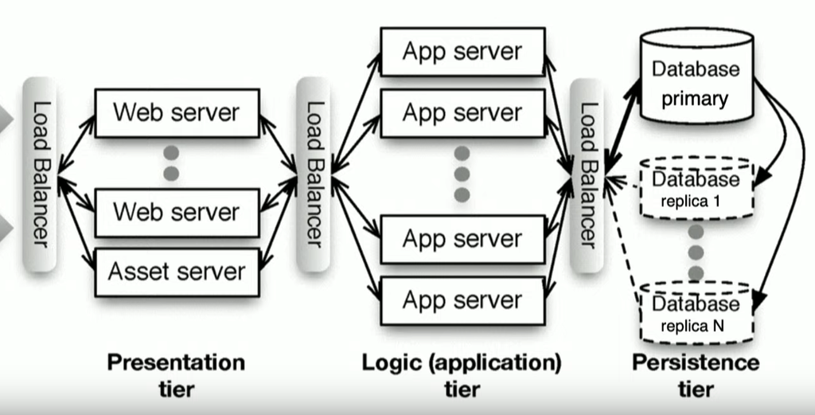

### Dynamic Content Generation

- Run a program to generate each ‘page’
- Originally, web used template with embedded code ‘snippets’
- Eventually, code moved out of the web server

## Database Scaling

### Sharding

- Partition across independent ‘shards’
- Scales great
- Bad when operations touch > 1 table
- Eg: good for user profile info

### Replication

- Replicate all data everywhere
- Good for multi-table queries
- Hard to scale b/c writes must propagate to all copies ⟹ temporary inconsistency in data values
- Example: social media ‘wall’ posts

## Parts of PaaS App Controlled by Dev

- App (controller and model)
- Database access
  - Avoid abusive queries
  - Use indices wisely
- View rendering
  - Use CSS selectors wisely (`id` and `class` is fast, but DOM traversal isn’t)
  - Cache ‘expensive’ fragments / partials in views
- Embedded assets (images, etc.) ≙ serve from dedicated static assets servers
- JavaScript ≙ load popular libraries from asset servers with generous expiration

## CICD

### Continuous Integration (CI)

- Integration testing the app beyond what each developer does
- Pre-release code checkin triggers CI
- Since frequent checkins, CI always running
- Common strategy: integrate with GitHub
- Good for:
  - Diagnosing differences between dev and prod envs
  - Cross-browser or cross-version testing
  - Testing SOA integration when remote services don’t act as planned
  - Hardening / protecting against attacks
  - Stress testing / longevity testing of new features / code paths

### Continuous Deployment (CD)

- Lots of deploys, very often
- Rational risk ≙ number of engineer-hours invested in product since last deploy
- Deployment should be a non-event; something that happens all of the time
  - Automate when possible
- Can configure to be deployed on push
  - Can be auto-integrated with CI
- Good for smaller features and non-customer facing changes
- Bad for (use releases for) big changes in how the user interacts with the app
  - Can tag commits to define releases with `git tag`
  - Have to push tags with `git push --tags`